# EDA_Data Exploration

```r
if(!require(easypackages)){install.packages("easypackages")}
library(easypackages)
packages("readr", "reshape2", "plyr", "dplyr", "ggplot2", "corrplot", "psych", "caret", prompt = FALSE)
#Remember - `plyr` before `dplyr`
```

## Basic Exploration Pair-wise correlations

Now that we have all our data transformed into numbers, we are ready to take a deeper look at it. Here we’ll build two functions, a pair-wise correlation function and a more complicated function to get the p-value and correlation for each feature pair in the data.

A great way to explore new data is to use a pairwise correlation matrix. This will measure the correlation between every combination of your variables. It doesn’t really matter if you have an outcome (or response) variable at this point, it will compare everything against everything else.

For those not familiar with the correlation coeﬃcient, it is simply a measure of similarity between two vectors of numbers. The measure value can range between 1 and -1, where 1 is perfectly correlated, -1 is perfectly inversly correlated, and 0 is not correlated at all:

```r
print(cor(1:5,1:5))#perfectly correlated
```

```
## [1] 1
```

```r
print(cor(1:5,seq(100,500,100)))#1,2,3,4,5  and 100, 200, 300, 400, 500
```

```
## [1] 1
```

```r
print(cor(1:5,5:1))#perfectly uncorrelated
```

```
## [1] -1
```

```r
print(cor(1:5,c(1,2,3,4,4)))
```

```
## [1] 0.9701425
```

We’ll use the mtcars data set that is already included in the R base package - it has the advantage of being fully numeric and clean.

```r
data_set <- mtcars
#d_cor <- as.matrix(cor(data_set))#Why as.matrix?
d_cor <- cor(data_set)
d_cor
```

```
##             mpg        cyl       disp         hp        drat         wt
## mpg   1.0000000 -0.8521620 -0.8475514 -0.7761684  0.68117191 -0.8676594
## cyl  -0.8521620  1.0000000  0.9020329  0.8324475 -0.69993811  0.7824958
## disp -0.8475514  0.9020329  1.0000000  0.7909486 -0.71021393  0.8879799
## hp   -0.7761684  0.8324475  0.7909486  1.0000000 -0.44875912  0.6587479
## drat  0.6811719 -0.6999381 -0.7102139 -0.4487591  1.00000000 -0.7124406
## wt   -0.8676594  0.7824958  0.8879799  0.6587479 -0.71244065  1.0000000
## qsec  0.4186840 -0.5912421 -0.4336979 -0.7082234  0.09120476 -0.1747159
## vs    0.6640389 -0.8108118 -0.7104159 -0.7230967  0.44027846 -0.5549157
## am    0.5998324 -0.5226070 -0.5912270 -0.2432043  0.71271113 -0.6924953
## gear  0.4802848 -0.4926866 -0.5555692 -0.1257043  0.69961013 -0.5832870
## carb -0.5509251  0.5269883  0.3949769  0.7498125 -0.09078980  0.4276059
##             qsec         vs          am       gear        carb
## mpg   0.41868403  0.6640389  0.59983243  0.4802848 -0.55092507
## cyl  -0.59124207 -0.8108118 -0.52260705 -0.4926866  0.52698829
## disp -0.43369788 -0.7104159 -0.59122704 -0.5555692  0.39497686
## hp   -0.70822339 -0.7230967 -0.24320426 -0.1257043  0.74981247
## drat  0.09120476  0.4402785  0.71271113  0.6996101 -0.09078980
## wt   -0.17471588 -0.5549157 -0.69249526 -0.5832870  0.42760594
## qsec  1.00000000  0.7445354 -0.22986086 -0.2126822 -0.65624923
## vs    0.74453544  1.0000000  0.16834512  0.2060233 -0.56960714
## am   -0.22986086  0.1683451  1.00000000  0.7940588  0.05753435
## gear -0.21268223  0.2060233  0.79405876  1.0000000  0.27407284
## carb -0.65624923 -0.5696071  0.05753435  0.2740728  1.00000000
```

For example, if you compare the two left utmost columns, we see that mpg is negatively correlated to cycl. Remember, correlations range from 1 to -1, with 1 being absolutely positively correlated, -1 being absolutely negatively correlated and 0 showing no correlations at all. `mpg cyl`  
`mpg 1.0000000 -0.8521620`

```r
d_cor_melt <- plyr::arrange(melt(d_cor), -(value))#hte minus sign simply orders values descending
print(paste("The number of records is: ", nrow(d_cor_melt)))
```

```
## [1] "The number of records is:  121"
```

```r
# clean up
pair_wise_correlation_matrix <- filter(d_cor_melt, Var1 != Var2)#remove perfect correlations
print(paste("The number of records is now: ", nrow(d_cor_melt)))
```

```
## [1] "The number of records is now:  121"
```

```r
pair_wise_correlation_matrix <- filter(pair_wise_correlation_matrix, is.na(value)==FALSE)
print(paste("The number of records is now: ", nrow(d_cor_melt)))
```

```
## [1] "The number of records is now:  121"
```

```r
# remove pair dups
head(pair_wise_correlation_matrix)
```

```
##   Var1 Var2     value
## 1 disp  cyl 0.9020329
## 2  cyl disp 0.9020329
## 3   wt disp 0.8879799
## 4 disp   wt 0.8879799
## 5   hp  cyl 0.8324475
## 6  cyl   hp 0.8324475
```

```r
pair_wise_correlation_matrix <-
     pair_wise_correlation_matrix[seq(1, nrow(pair_wise_correlation_matrix), by=2),]#remove every other row

print(paste("The number of records is now: ", nrow(pair_wise_correlation_matrix)))
```

```
## [1] "The number of records is now:  55"
```

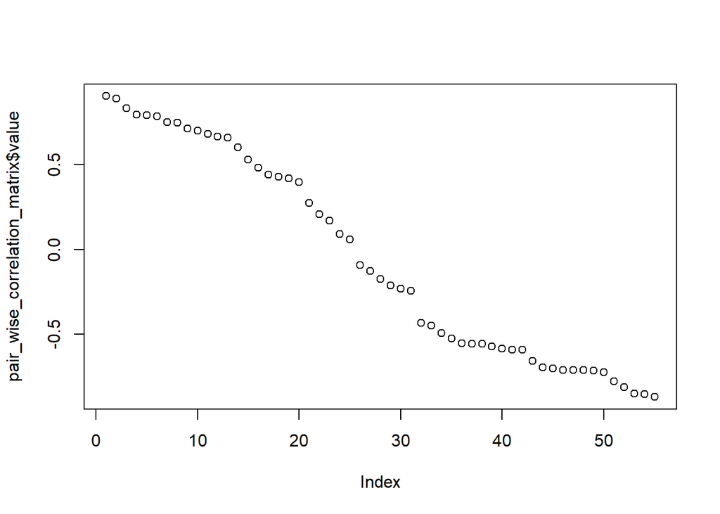

```r
plot(pair_wise_correlation_matrix$value)
```

The plot above shows there are variables that are highly correlated in the top lift and negatively correlated in the lower right. The ones in the middle are more random with little correlation.

Lets build the above into a function:

```r
Get_Fast_Correlations <- function(data_set, features_to_ignore=c(), size_cap=5000) {
     data_set <- data_set[, setdiff(names(data_set), features_to_ignore)]
     if (size_cap > nrow(data_set)) {
          data_set = data_set[sample(nrow(data_set), size_cap),]
     } else {
               data_set = data_set[sample(nrow(data_set), nrow(data_set)),]
          }
     d_cor <- as.matrix(cor(data_set))
     d_cor_melt <- arrange(melt(d_cor), -(value))
     # clean up
     pair_wise_correlation_matrix <- filter(d_cor_melt, Var1 != Var2)
     pair_wise_correlation_matrix <- filter(pair_wise_correlation_matrix, is.na(value)==FALSE)
     # remove pair dups
     #dim(pair_wise_correlation_matrix)
     pair_wise_correlation_matrix <- pair_wise_correlation_matrix[seq(1,
                                   nrow(pair_wise_correlation_matrix), by=2), ]
     #dim(pair_wise_correlation_matrix)
     plot(pair_wise_correlation_matrix$value)#optional
     return(pair_wise_correlation_matrix)
}
```

## `psych` Package Correlation & Significance

We use the psych (https://cran.r-project.org/web/packages/psych/index.html) library to do a lot of the heavy lifting. Delegate all the math to the corr.test function. It returns the following results (from the help ﬁles and plenty more there: ?corr.test):

- **r**: The matrix of correlations - just like above
- **n**: Number of cases per correlation
- **t**: Value of t-test for each correlation
- **p**: Two tailed probability of t for each correlation
- **se**: Standard error of the correlation
- **ci**: The alpha/2 lower and upper values

```r
data_set <- mtcars
featurenames_copy <- names(data_set)#psych uses it own nam,s - lets keep the meaningful ones
# strip var names to index for pair wise identification
names(data_set) <- seq(1:ncol(data_set))
head(data_set)
```

```
##                      1 2   3   4    5     6     7 8 9 10 11
## Mazda RX4         21.0 6 160 110 3.90 2.620 16.46 0 1  4  4
## Mazda RX4 Wag     21.0 6 160 110 3.90 2.875 17.02 0 1  4  4
## Datsun 710        22.8 4 108  93 3.85 2.320 18.61 1 1  4  1
## Hornet 4 Drive    21.4 6 258 110 3.08 3.215 19.44 1 0  3  1
## Hornet Sportabout 18.7 8 360 175 3.15 3.440 17.02 0 0  3  2
## Valiant           18.1 6 225 105 2.76 3.460 20.22 1 0  3  1
```

```r
cor_data_df <-  psych::corr.test(data_set)
cor_data_df$r#correlations
```

```
##             1          2          3          4           5          6
## 1   1.0000000 -0.8521620 -0.8475514 -0.7761684  0.68117191 -0.8676594
## 2  -0.8521620  1.0000000  0.9020329  0.8324475 -0.69993811  0.7824958
## 3  -0.8475514  0.9020329  1.0000000  0.7909486 -0.71021393  0.8879799
## 4  -0.7761684  0.8324475  0.7909486  1.0000000 -0.44875912  0.6587479
## 5   0.6811719 -0.6999381 -0.7102139 -0.4487591  1.00000000 -0.7124406
## 6  -0.8676594  0.7824958  0.8879799  0.6587479 -0.71244065  1.0000000
## 7   0.4186840 -0.5912421 -0.4336979 -0.7082234  0.09120476 -0.1747159
## 8   0.6640389 -0.8108118 -0.7104159 -0.7230967  0.44027846 -0.5549157
## 9   0.5998324 -0.5226070 -0.5912270 -0.2432043  0.71271113 -0.6924953
## 10  0.4802848 -0.4926866 -0.5555692 -0.1257043  0.69961013 -0.5832870
## 11 -0.5509251  0.5269883  0.3949769  0.7498125 -0.09078980  0.4276059
##              7          8           9         10          11
## 1   0.41868403  0.6640389  0.59983243  0.4802848 -0.55092507
## 2  -0.59124207 -0.8108118 -0.52260705 -0.4926866  0.52698829
## 3  -0.43369788 -0.7104159 -0.59122704 -0.5555692  0.39497686
## 4  -0.70822339 -0.7230967 -0.24320426 -0.1257043  0.74981247
## 5   0.09120476  0.4402785  0.71271113  0.6996101 -0.09078980
## 6  -0.17471588 -0.5549157 -0.69249526 -0.5832870  0.42760594
## 7   1.00000000  0.7445354 -0.22986086 -0.2126822 -0.65624923
## 8   0.74453544  1.0000000  0.16834512  0.2060233 -0.56960714
## 9  -0.22986086  0.1683451  1.00000000  0.7940588  0.05753435
## 10 -0.21268223  0.2060233  0.79405876  1.0000000  0.27407284
## 11 -0.65624923 -0.5696071  0.05753435  0.2740728  1.00000000
```

```r
# apply var names to correlation matrix over index
rownames(cor_data_df$r) <- featurenames_copy
colnames(cor_data_df$r) <- featurenames_copy
names(cor_data_df)
```

```
## [1] "r"      "n"      "t"      "p"      "se"     "adjust" "sym"    "ci"
## [9] "Call"
```

```r
cor_data_df
```

```
## Call:psych::corr.test(x = data_set)
## Correlation matrix
##        mpg   cyl  disp    hp  drat    wt  qsec    vs    am  gear  carb
## mpg   1.00 -0.85 -0.85 -0.78  0.68 -0.87  0.42  0.66  0.60  0.48 -0.55
## cyl  -0.85  1.00  0.90  0.83 -0.70  0.78 -0.59 -0.81 -0.52 -0.49  0.53
## disp -0.85  0.90  1.00  0.79 -0.71  0.89 -0.43 -0.71 -0.59 -0.56  0.39
## hp   -0.78  0.83  0.79  1.00 -0.45  0.66 -0.71 -0.72 -0.24 -0.13  0.75
## drat  0.68 -0.70 -0.71 -0.45  1.00 -0.71  0.09  0.44  0.71  0.70 -0.09
## wt   -0.87  0.78  0.89  0.66 -0.71  1.00 -0.17 -0.55 -0.69 -0.58  0.43
## qsec  0.42 -0.59 -0.43 -0.71  0.09 -0.17  1.00  0.74 -0.23 -0.21 -0.66
## vs    0.66 -0.81 -0.71 -0.72  0.44 -0.55  0.74  1.00  0.17  0.21 -0.57
## am    0.60 -0.52 -0.59 -0.24  0.71 -0.69 -0.23  0.17  1.00  0.79  0.06
## gear  0.48 -0.49 -0.56 -0.13  0.70 -0.58 -0.21  0.21  0.79  1.00  0.27
## carb -0.55  0.53  0.39  0.75 -0.09  0.43 -0.66 -0.57  0.06  0.27  1.00
## Sample Size
## [1] 32
## Probability values (Entries above the diagonal are adjusted for multiple tests.)
##       1 2    3    4    5    6    7    8    9   10   11
## 1  0.00 0 0.00 0.00 0.00 0.00 0.22 0.00 0.01 0.10 0.02
## 2  0.00 0 0.00 0.00 0.00 0.00 0.01 0.00 0.04 0.08 0.04
## 3  0.00 0 0.00 0.00 0.00 0.00 0.20 0.00 0.01 0.02 0.30
## 4  0.00 0 0.00 0.00 0.17 0.00 0.00 0.00 1.00 1.00 0.00
## 5  0.00 0 0.00 0.01 0.00 0.00 1.00 0.19 0.00 0.00 1.00
## 6  0.00 0 0.00 0.00 0.00 0.00 1.00 0.02 0.00 0.01 0.20
## 7  0.02 0 0.01 0.00 0.62 0.34 0.00 0.00 1.00 1.00 0.00
## 8  0.00 0 0.00 0.00 0.01 0.00 0.00 0.00 1.00 1.00 0.02
## 9  0.00 0 0.00 0.18 0.00 0.00 0.21 0.36 0.00 0.00 1.00
## 10 0.01 0 0.00 0.49 0.00 0.00 0.24 0.26 0.00 0.00 1.00
## 11 0.00 0 0.03 0.00 0.62 0.01 0.00 0.00 0.75 0.13 0.00
##
##  To see confidence intervals of the correlations, print with the short=FALSE option
```

Let’s visualize our correlation results using cor.plot from the [psych] (https://cran.r-project.org/web/packages/psych/index.html) library and corrplot.mixed from the [corrplot] (https://cran.r-project.org/web/packages/corrplot/vignettes/corrplot-intro.html)library.

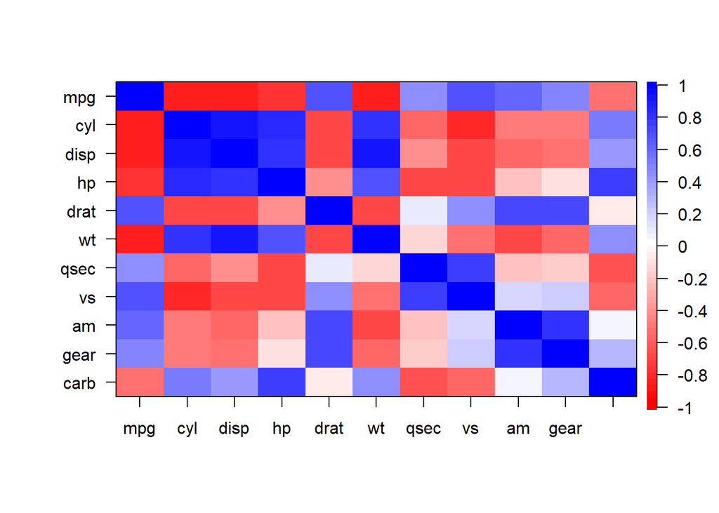

```r
psych::cor.plot(cor_data_df$r)
```

Or even prettier with the `corrplot` library:

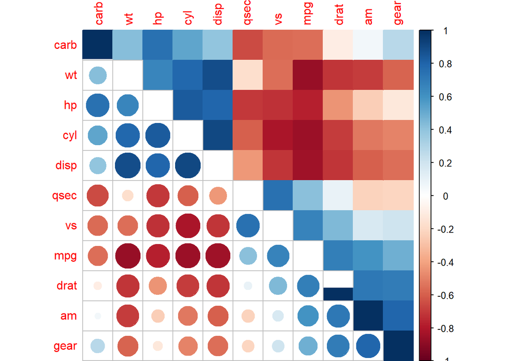

```r
corrplot.mixed(cor_data_df$r, lower="circle", upper="color", tl.pos="lt", diag="n",
               order="hclust", hclust.method="complete")
```

We are not going to add these plotting functions into our pipeline but will create a function using the corr.test results to highlight the strongest relationships.

Lets build our pipeline function, discard all results except for the signiﬁcance (p-value) and correlations and set our cut-oﬀ thresholds:

```r
Get_Top_Relationships <- function(data_set, correlation_abs_threshold=0.8, pvalue_threshold=0.01) {
     feature_names <- names(data_set)
     # strip var names to index for pair-wise identification
     names(data_set) <- seq(1:ncol(data_set))
     # calculate correlation and significance numbers
     cor_data_df <-  psych::corr.test(data_set)
     # apply var names to correlation matrix over index
     rownames(cor_data_df$r) <- feature_names
     colnames(cor_data_df$r) <- feature_names
     # top cor and sig
     relationships_set <- cor_data_df$ci[,c('r','p')]
     # apply var names to data over index pairs
     relationships_set$feature_1 <- feature_names[as.numeric(sapply(strsplit(rownames(relationships_set), "-"), `[`, 1))]
     relationships_set$feature_2 <- feature_names[as.numeric(sapply(strsplit(rownames(relationships_set), "-"), `[`, 2))]
     relationships_set <- select(relationships_set, feature_1, feature_2, r, p) %>% dplyr::rename(correlation=r, pvalue=p)
     # return only the most insteresting relationships
     return(filter(relationships_set, abs(correlation) > correlation_abs_threshold | pvalue < pvalue_threshold) %>%
                 arrange(pvalue))
}
```

```r
data_set <- mtcars
dim(Get_Top_Relationships(mtcars))
```

```
## [1] 39  4
```

```r
head(Get_Top_Relationships(mtcars))
```

```
##   feature_1 feature_2 correlation       pvalue
## 1       cyl      disp   0.9020329 1.803002e-12
## 2      disp        wt   0.8879799 1.222311e-11
## 3       mpg        wt  -0.8676594 1.293958e-10
## 4       mpg       cyl  -0.8521620 6.112688e-10
## 5       mpg      disp  -0.8475514 9.380328e-10
## 6       cyl        hp   0.8324475 3.477861e-09
```

## findCorrelations $ `caret`

Recall previously we looked a nearZeroVar.

findCorrelation is fast without detail.

```r
data_set <- mtcars
d_cor <- cor(data_set)
d_cor
```

```
##             mpg        cyl       disp         hp        drat         wt
## mpg   1.0000000 -0.8521620 -0.8475514 -0.7761684  0.68117191 -0.8676594
## cyl  -0.8521620  1.0000000  0.9020329  0.8324475 -0.69993811  0.7824958
## disp -0.8475514  0.9020329  1.0000000  0.7909486 -0.71021393  0.8879799
## hp   -0.7761684  0.8324475  0.7909486  1.0000000 -0.44875912  0.6587479
## drat  0.6811719 -0.6999381 -0.7102139 -0.4487591  1.00000000 -0.7124406
## wt   -0.8676594  0.7824958  0.8879799  0.6587479 -0.71244065  1.0000000
## qsec  0.4186840 -0.5912421 -0.4336979 -0.7082234  0.09120476 -0.1747159
## vs    0.6640389 -0.8108118 -0.7104159 -0.7230967  0.44027846 -0.5549157
## am    0.5998324 -0.5226070 -0.5912270 -0.2432043  0.71271113 -0.6924953
## gear  0.4802848 -0.4926866 -0.5555692 -0.1257043  0.69961013 -0.5832870
## carb -0.5509251  0.5269883  0.3949769  0.7498125 -0.09078980  0.4276059
##             qsec         vs          am       gear        carb
## mpg   0.41868403  0.6640389  0.59983243  0.4802848 -0.55092507
## cyl  -0.59124207 -0.8108118 -0.52260705 -0.4926866  0.52698829
## disp -0.43369788 -0.7104159 -0.59122704 -0.5555692  0.39497686
## hp   -0.70822339 -0.7230967 -0.24320426 -0.1257043  0.74981247
## drat  0.09120476  0.4402785  0.71271113  0.6996101 -0.09078980
## wt   -0.17471588 -0.5549157 -0.69249526 -0.5832870  0.42760594
## qsec  1.00000000  0.7445354 -0.22986086 -0.2126822 -0.65624923
## vs    0.74453544  1.0000000  0.16834512  0.2060233 -0.56960714
## am   -0.22986086  0.1683451  1.00000000  0.7940588  0.05753435
## gear -0.21268223  0.2060233  0.79405876  1.0000000  0.27407284
## carb -0.65624923 -0.5696071  0.05753435  0.2740728  1.00000000
```

```r
top_correlations <- findCorrelation(d_cor, cutoff = 0.8, verbose = FALSE)#cutoff is above and below .8
top_correlations
```

```
## [1] 2 3 1
```

```r
names(data_set)[top_correlations]
```

```
## [1] "cyl"  "disp" "mpg"
```

## Outlier Detection

There are diﬀerent ways of hunting down outliers in a data set but a simple approach is to take the mean or the median of the data and look for any points beyond x standard deviations [68–95–99.7 rule] (https://en.wikipedia.org/wiki/68%E2%80%9395%E2%80%9399.7_rule)

```r
wt_mean <- mean(mtcars$wt)
wt_mean
```

```
## [1] 3.21725
```

```r
wt_sd <- sd(mtcars$wt)
wt_sd
```

```
## [1] 0.9784574
```

How many points in wt are outside the 1 sd band?

```r
sum((mtcars$wt > (wt_mean + (wt_sd/2))) | (mtcars$wt < (wt_mean - (wt_sd/2))))
```

```
## [1] 17
```

```r
mtcars$wt[(mtcars$wt > (wt_mean + (wt_sd/2))) | (mtcars$wt < (wt_mean - (wt_sd/2)))]
```

```
##  [1] 2.620 2.320 4.070 3.730 3.780 5.250 5.424 5.345 2.200 1.615 1.835
## [12] 2.465 3.840 3.845 1.935 2.140 1.513
```

Lets create a simple but useful function to measure the standard deviation of each feature and detect outliers. This function reports outliers but it can also remove the oﬀending feature with the remove_outlying_features function parameter. With just a few extra lines of code it could just as easily impute extreme values down to the mean, 0 or min/max:

```r
#If features are text or date and have not gone thru numerical handling, it would fail - use features_to_ignore
Identify_Outliers <- function(data_set, features_to_ignore=c(),
               outlier_sd_threshold = 2, remove_outlying_features = FALSE) {
               # get standard deviation for each feature
               outliers <- c()
               for (feature_name in setdiff(names(data_set), features_to_ignore)) {
                    feature_mean <- mean(data_set[,feature_name], na.rm = TRUE)
                    feature_sd <- sd(data_set[,feature_name], na.rm = TRUE)
                    outlier_count <- sum(data_set[,feature_name] > (feature_mean + (feature_sd * outlier_sd_threshold)) |
                                         data_set[,feature_name] < (feature_mean - (feature_sd * outlier_sd_threshold)))
                    if (outlier_count > 0) {
                         outliers <- rbind(outliers, c(feature_name, outlier_count))
                         if (remove_outlying_features)
                              data_set[, feature_name] <- NULL
                    }
               }
          outliers <- data.frame(outliers) %>% rename(feature_name = X1, outlier_count= X2) %>%
               mutate(outlier_count=as.numeric(as.character(outlier_count))) %>% arrange(desc(outlier_count))
          if (remove_outlying_features) {
               return(data_set)
          } else {
               return(outliers)
          }
     }
```

```r
head(Identify_Outliers(mtcars, remove_outlying_features=FALSE))
```

```
##   feature_name outlier_count
## 1           wt             3
## 2          mpg             2
## 3           hp             1
## 4         drat             1
## 5         qsec             1
## 6         carb             1
```

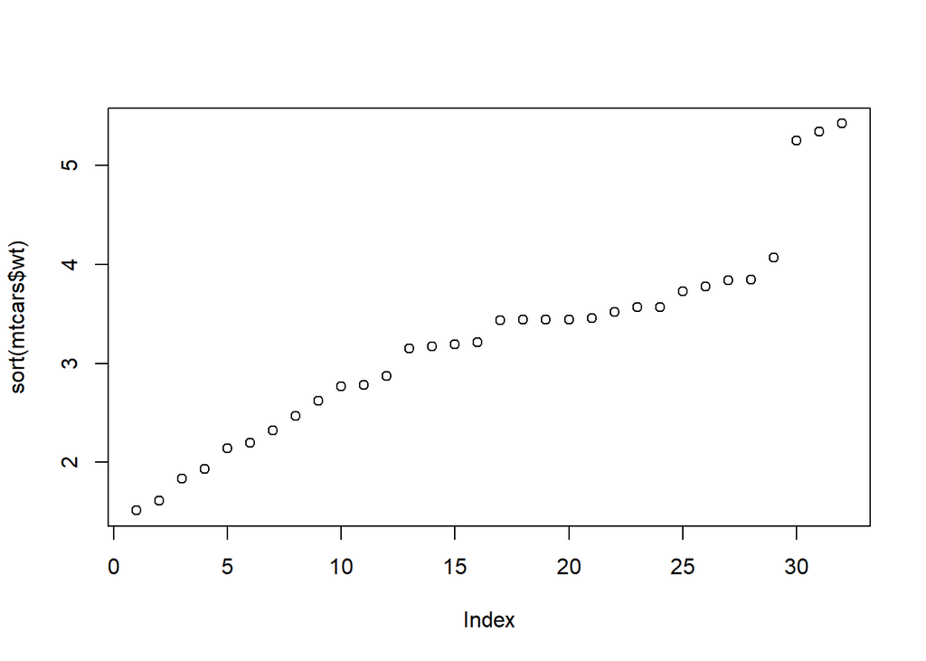

```r
plot(sort(mtcars$wt))
```

## Notes:

- If there is a high correlation between your dependent and independent variable, then you are lucky and found a predictive feature for your supervised model.
- If there is a lot of correlation between your dependent variables then you found redundant features and you can remove one side of the correlation pair. This is actually recommended in linear models.
- Multicollinearity hurts linear models and correlation checks can help clean things up. This is not as important for classification models except when you want to prune your feature set down, or if you want to use variable importance in a report, too many overlapping features will complicate things.